# My STSM Experience at Durham University

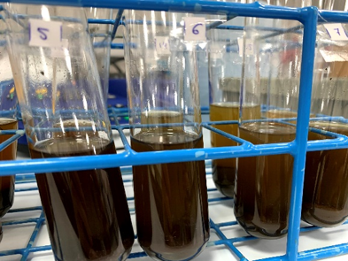

In June and July 2026, Tobias Schneider visited Durham University to compare fecal-biomarker workflows between the Eawag and Durham laboratories, contributing to harmonized protocols and FAIR data standards for sedimentary fecal-biomarker research.

Author

Tobias Schneider

Published

July 29, 2026

Modified

October 26, 2026

In late June and early July 2026, I spent two weeks at Durham University comparing fecal-biomarker workflows between the Durham and Eawag laboratories as part of my STSM “SEDI-FAIR: Sedimentary fecal biomarker workflow, metadata, and data harmonization for FAIR datasets”, funded by the PalaeOpen COST Action.

### 👨‍🔬 Who?

**Dr. Tobias Schneider**

Swiss Federal Institute of Aquatic Science and Technology (Eawag), Switzerland

Contact: www.drtobiasschneider.com

### 🌍 Where?

Durham University, United Kingdom

Hosted by Prof. Dr. Helen Mackay

### 📅 When?

19 June to 4 July 2026

## Tracing people and animals through sedimentary molecules

Fecal biomarkers, including sterols and bile acids, are molecular traces that can remain preserved in soils and sediments for millennia. They provide evidence of the past presence of humans and livestock and can help us reconstruct domestication, land use, and human impacts on ecosystems. Interest in these proxies is therefore growing beyond the biomarker community, including among archaeologists and researchers working with sedimentary and environmental ancient DNA.

However, laboratories still differ considerably in how they extract and analyze these compounds, and even in how they name and report them. These differences make results harder to compare and datasets more difficult to combine or reuse.

This challenge was discussed at the COST Action PalaeOpen biomarker workshop in Potsdam in March 2026. Building on those discussions, my STSM aimed to compare the workflows used at Durham and Eawag, contribute to common terminology and reporting standards, and lay the groundwork for an inter-laboratory fecal-biomarker reference library.

## Comparing workflows at the laboratory bench

Most of the visit was devoted to hands-on laboratory work with the Durham team. Over eight full laboratory days, we processed 26 samples from archaeological sites in Stavanger, Norway, and from Lake Rotsee in Switzerland. The Stavanger material provided an archaeologically relevant soil archive, while the Rotsee samples represented a lake-sediment archive. Together, they allowed us to compare the workflows using contrasting sample types.

At Eawag, we typically extract lipids using either a Bligh–Dyer extraction or Accelerated Solvent Extraction, whereas the Durham laboratory uses microwave-assisted extraction. The subsequent steps are more similar: both laboratories use flash-column chromatography to clean and separate the total lipid extracts, followed by liquid-liquid extraction to isolate a neutral fraction containing sterols and an acid fraction containing bile acids.

Working through the procedures side by side allowed us to identify precisely where the methods diverge and where they are already comparable. It also highlighted practical details that are rarely captured fully in written protocols but may nevertheless influence analytical results.

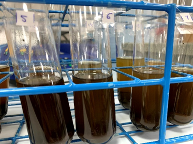

(a) a) Total lipid extracts following microwave-assisted extraction at Durham University

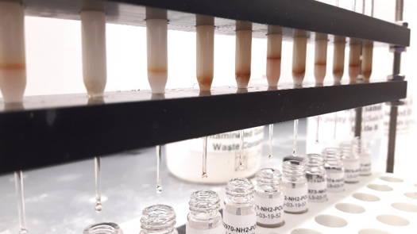

(b) b) Flash-column chromatography of the total lipid extracts

1. Total lipid extracts following microwave-assisted extraction at Durham University; b) flash-column chromatography of the total lipid extracts. Photo credits: Helen Mackay and Tobias Schneider.

Figure 1

As often happens in laboratory research, not everything went according to schedule. The GC-MS instruments at Durham were unavailable during the STSM, meaning that we could not complete the planned instrumental analyses. We therefore divided the prepared fractions for complementary measurements at Eawag and Durham. Once these analyses are complete, the paired results will allow us to quantitatively assess the effects of the different workflows and finalize the harmonized protocol.

Despite this change of plan, the visit produced several tangible outcomes: 26 processed samples, paired fractions for inter-laboratory measurement, a detailed comparison of the two workflows, and a clear experimental plan for resolving the remaining differences.

## From laboratory protocols to FAIR data

The mission extended beyond the laboratory work. Helen and I began outlining a lipid-biomarker-based Human Traces index: a standardized framework for combining and reporting lipid biomarker evidence of past human activity. This will contribute to a broader standardization initiative within the PAGES Human Traces Working Group.

We also adapted the database component of the STSM in response to developments since the Potsdam workshop. Our original plan was to refine metadata templates and test fecal-biomarker uploads using an offline version of the Neotoma Paleoecology Database. However, it became clear that meaningful data integration first requires an agreed controlled vocabulary.

We therefore contributed to the Biomarkers in Geosciences Controlled Vocabulary (Big-CV), particularly to the working groups addressing bile acids and glycerol dialkyl glycerol tetraethers (GDGTs). Big-CV covers multiple biomarker classes, allowing me to contribute my existing GDGT expertise alongside our work on sterols and bile acids. Defining consistent compound names and synonyms is essential for making biomarker datasets findable, accessible, interoperable, and reusable — the principles at the heart of FAIR data. Test uploads to the offline Neotoma environment will follow once this terminology has been agreed upon.

Finally, we developed a strategy for creating a fecal-biomarker reference library using dung from livestock species and heritage breeds relevant to archaeological contexts. Such a collection could provide a benchmark for identifying fecal sources in archaeological and palaeoenvironmental records, while also supporting training and future inter-laboratory comparisons.

## Building a community, not just a protocol

The most valuable outcome of my STSM was not something I could pack into a sample vial or record in a protocol: it was becoming part of Durham’s research community for two weeks. Shared lunches and coffee breaks, a field trip to the Lake District, and many inspiring conversations with researchers and students were among the highlights of my stay. Presenting my work in a departmental seminar provided another valuable opportunity for exchange. And of course, the occasional evening game at a local pub was also part of the experience.

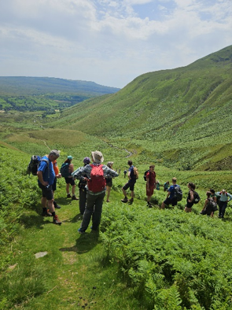

Figure 2: Field trip to the Lake District during the late-June heatwave. Photo credit: Tobias Schneider.

These encounters sparked new ideas, but their most lasting outcome was the close working relationship established between the Durham and Eawag laboratories. We now understand better where our workflows align, where they still differ, and how we can reconcile those differences through targeted analyses.

We also have a concrete plan for using the dung reference samples to train colleagues at Eawag in the shared workflow while beginning to build a community reference library. Bringing together methodological exchange, shared reference materials, and coordinated data standards is an important step toward making fecal-biomarker records more comparable and useful across disciplines.

Over the coming months, we will complete the instrumental analyses and quantitative workflow comparison at Eawag, contribute to finalizing the Big-CV terminology, and continue developing the Human Traces index protocol. The broader reference-library concept was presented at EGU26, before the STSM, and the results of this visit will now inform our contribution to INQUA27 and a planned publication centered on the benchmark reference library.

In this way, a two-week laboratory visit is developing into a much longer-term collaboration, connecting not only protocols, samples, and datasets, but also people. Researchers interested in contributing reference materials or participating in future inter-laboratory comparisons are warmly invited to get in touch.

## Acknowledgements

I am very grateful to Prof. Dr. Helen Mackay and the entire biomarker team at Durham University for their warm welcome, hands-on collaboration, and generosity with their time, expertise, and laboratory space. I would also like to thank my colleagues at Eawag for supporting the project and helping to keep the complementary analyses on track.

Finally, I thank the PalaeOpen COST Action for making this scientific exchange possible and for supporting the collaboration needed to turn individual laboratory workflows into shared community resources.

*This STSM was funded by COST Action CA23116 — PalaeOpen.*

Back to top